# GDP as a Predictor of Unemployment: U.S. Analysis

2025-11-12

### TEAM: Ebenezer Tagro, Jake Webber, Edward Kim, Samantha Kwon

## Introduction:

Economic growth and employment rates are the primary indicators used to gauge a nation’s economic health. As the economy expands, businesses are more likely to allocate resources towards investment and recruitment. Similarly, an economic recession usually leads to layoffs and rising unemployment. Understanding whether these changes assist in predicting the rates of unemployment can potentially forecast inflationary periods and recessions. Our team’s research attempts to observe a potential relationship between Gross Domestic Product (GDP) and unemployment rate in the U.S., and how this relationship can predict employment rate in 2025.

Thesis: Is there a negative relationship between the rise of the Gross Domestic Product and the levels of unemployment in the United States?

## Background:

The U.S. definitions for specific statistics, like labor force and unemployment, differ from other U.N. countries upholding the International Labour Organization (ILO) code. The U.S. defines the labor force as any person age 16 and above, and either employed or unemployed. To be considered unemployed, one cannot be employed, actively seeking work, or available for work. Alternatively, GDP is fundamentally designed as an evaluation of the final goods and services produced within a nation. When looking at the percentage change between two separate years of a country’s GDP it can help gauge how the nation has been doing within that time period. This value of product can help determine how fast a nation is growing, as well as more specifically which states and industries are growing or failing as well.

Environmental factors contribute to the fluctuations in GDP and unemployment rates, which explains the noticeable outliers in our graphs. Looking at the “Unemployment Rate Over Time” graph, data between 2020 and 2022 deviates from the trends depicted in other years[^3], due to the economic recession at the time caused by Covid-19[^4].

Unusual outliers in our data are related to the Covid-19 epidemic and the economic recession that occurred. The epidemic shut down businesses across the U.S., leading to a lower job market and less economic production. Like other recessions, such as the Great Depression and the Great Recession (2007-2009), these events leave serious implications on the unemployment rate and GDP in the moment and the surrounding time intervals; however, a general pattern persists when comparing the data from 2017-2024. An increase in GDP leads to a decrease in the unemployment rate, revealing a negative relationship.

## Analysis:

To begin our group created a graph of Unemployment Rate Over Time from 2015 to 2025.

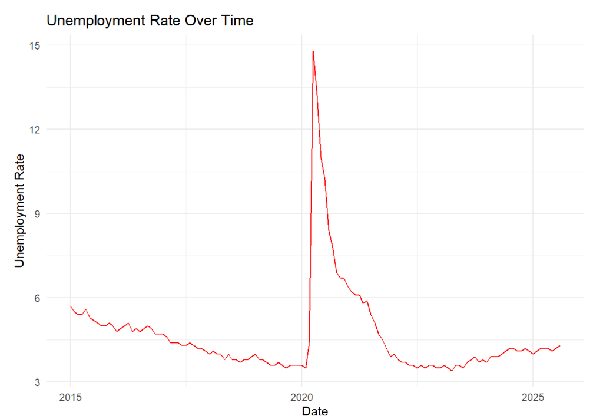

Unemployment Graph

We analyzed the Unemployment Rate Graph and looked at the 2020 data and we saw that because of the Covid-19 epidemic, there is a noticeable fluctuation in the U.S. unemployment rate.

The second graph we created represents GDP percent change for the previous year over time from 2017 to 2024.

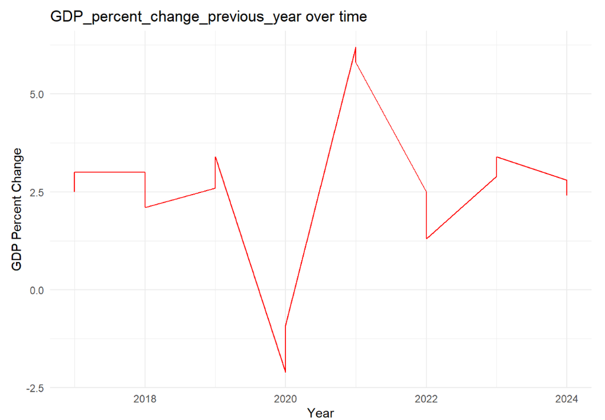

GDP Percent Change Graph

We were looking to compare the Unemployment Rate Over Time to GDP Percent Change Graph by looking once again at the 2020 data. We saw that in the GDP Percent Change Graph, U.S. GDP drops sharply. The two initial graphs help demonstrate a general understanding that in most cases GDP percent change and the unemployment rate move in opposite directions.

To further examine this relationship, our team created a scatter plot based on the sample 7 year period. The addition of a linear line of best fit to this scatter plot visualized a negative relationship between GDP percent change and unemployment rate.

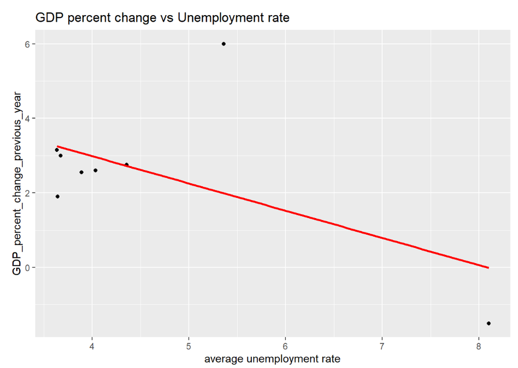

GDP Percent Change Graph and Unemployment Rate

It’s important to understand that for economics and statistics, it is difficult to predict the unemployment rate for 2025 using solely GDP percent changes per year because the relationship between the two is not perfectly linear. Several other variables affect the unemployment rate (i.e. technological advances, education, unemployment rate, recessions, globalization, ect.). In our sample data from 2017-2024; a projection of the GDP percent changes and the unemployment rate were created to aid in making a prediction for the 2025 unemployment rate.

Our team created a hypothesis test to determine whether the data could accurately determine if GDP percent change and the unemployment rate were negatively related. The null hypothesis states the GDP percent change and the unemployment rate were unrelated, and the alternate hypothesis states the GDP percent and the unemployment rate were negatively related. For clarity, our team denoted B1 equal to slope or how much the unemployment rate changes when GDP percent change increases or decreases.

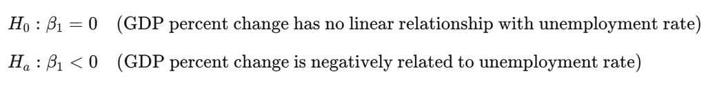

Hypothesis Test

After creating the hypothesis, our team created a linear regression model to statistically reveal a possible relationship: Unemployment rate = B0 + B1 (GDP Percent Change (Previous Year)). This general equation demonstrates B0 as the predicted unemployment rate when GDP percent change of previous year is 0, and B1 represents how much the unemployment rate can be expected to change when GDPpercent change increases by one percent. Inputting the figures from the regression model details the following equation: Unemployment rate = 5.6329 -.4094(GDP Percent Change t-1).

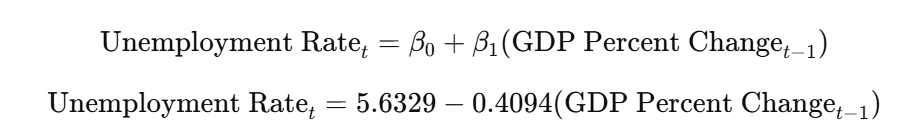

Regression Equation

Ultimately, the data showed that the estimated slope (B1 = -.4094) was negative, which can help suggest that GDP percent change is negatively related to unemployment. Turning attention to the t-value (-1.602), this reveals a plausible negative relationship. Analyzing the absolute value of our t-value, the result’s proximity to 0 cannot be considered significant. This conclusion leads to examination of our data’s p-value (.160), a value greater than.05 and .10, indicating that the null hypothesis cannot be rejected. In summary, the linear regression model aids in understanding that from 2017 - 2024, there is a negative trend between GDP percent change and the unemployment rate; however, there is insufficient evidence to suggest that GDP percent change predicts unemployment rate in a linear manner though the data collected points in that direction.

Using regression the model a predication for 2025 unemployment rate was created based on the GDP percent change that was observed in 2024. This model predicted 4.568548 as the unemployment rate for 2025. While this trend does accurately represent the negative trend suggested by the data (that GDP percent change is often negatively impacted by unemployment rates) it is important to understand that this is not the definitive answer because B1 was not statistically significant enough to make that claim.

To conclude our data analysis, our team created the confidence intervals. The first confidence interval was for the slope of the regression model, falling between [-1.034801 , .2160367 ]. This data does not generate sufficient evidence to conclude that GDP percent change was statistically meaningful because zero was included in this interval. The second confidence interval was for possible values of the actual unemployment rate for 2025; the range is approximately [.98,8.16]. Because of the interval’s width, it is difficult to tell exactly where unemployment falls in this range. Ultimately, the confidence intervals show the importance of understanding that other factors affect the unemployment rate, and a model based solely on GDP may not capture the full scope of the unemployment rate movements.

# Hypothesis Test:

To reiterate the hypothesis test; The null hypothesis states the GDP percent change and the unemployment rate are unrelated, while the alternate hypothesis states the GDP percent and the unemployment rate are negatively related (B1 = slope or how much unemployment rate changes when GDP percent change increases or decreases). In all, our data failed to reject the null hypothesis.

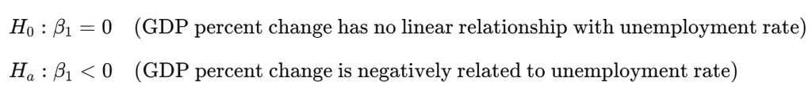

Hypothesis Test

# Confidence Intervals:

To conclude our data analysis, our team created the confidence intervals. The first confidence interval was for the slope of the regression model, falling between [-1.034801 , .2160367 ]. This data does not generate sufficient evidence to conclude that GDP percent change was statistically meaningful because zero was included in this interval. The second confidence interval was for possible values of the actual unemployment rate for 2025; the range is approximately [.98,8.16]. Because of the interval’s width, it is difficult to tell exactly where unemployment falls in this range. Ultimately, the confidence intervals show the importance of understanding that other factors affect the unemployment rate, and a model based solely on GDP may not capture the full scope of the unemployment rate movements.

## Discussion:

# Interpretation of Results:

Using this regression model, our team also forecasted the unemployment rate in 2025 based only on the 2024 GDP percent change. Inputting the 2024 GDP growth rate of 2.6% into our model gives a predicted unemployment rate of about 4.57% for 2025. This estimate falls within the range of unemployment rates seen in our sample and supports the idea that moderate, positive GDP growth is typically linked to relatively low—but not zero—unemployment. However, since the model is simple and relies on a short time frame, this prediction should be viewed as a general example of how the model can be applied rather than as a precise economic forecast.

# Limitations of the Analysis:

Despite the patterns that were seen, there are several important limitations to our analysis. First, the relationship that our team identified is correlational, not causal. Many other factors affect unemployment besides GDP growth, including technological change, demographic trends, education levels, sector-specific shocks, monetary and fiscal policy, and long-term changes in the labor market. Because our regression only uses GDP percent change to explain unemployment, our team cannot rule out the chance that both variables are influenced by deeper underlying forces or that omitted factors are affecting our estimates. For this reason, our team cannot confidently say changes in GDP “cause” changes in unemployment based on our analysis alone. Second, our choices and changes in data come with their own limitations. Our team combined monthly unemployment and GDP data to create yearly averages. This smooths out important differences within the year and prevents us from looking at the specific timing of changes in GDP and unemployment. The sample period from 2017 to 2024 is also quite short, so any conclusions our team came to are based on a limited number of annual observations. These may not apply to other time periods. Additionally, the official unemployment rate our team uses is the standard BLS measure of the “civilian” labor force. This measure leaves out certain groups, including incarcerated individuals, some discouraged workers, and people in informal or unstable jobs. Because there are ongoing discussions about how accurately this statistic represents the real state of the labor market, our unemployment data might underestimate or misrepresent actual joblessness in the United States.

# Conclusion:

In summary, our team’s project finds evidence of a negative association between GDP growth and the unemployment rate in the United States from 2017 to 2024. The time-series line graphs show that years with weak or negative GDP growth coincide with higher unemployment, while years of stronger growth align with lower unemployment. The scatterplot of average unemployment against GDP percent change, along with the fitted regression line, highlights this inverse relationship: within our sample, higher GDP growth tends to go hand in hand with lower unemployment. Our regression model estimates a negative slope and predicts an unemployment rate of about 4.57% for 2025 based on 2024 GDP growth, reinforcing this pattern. However, statistical tests do not provide strong evidence to reject the null hypothesis of no linear relationship. Overall, these results make sense with standard economic intuition and Okun’s law: when the economy grows faster, unemployment tends to fall. When growth stalls or reverses, unemployment usually rises. At the same time, our analysis is limited by its short time frame, a narrow set of variables, and dependence on official summary statistics. The main contribution of our work is not to prove causation but to document and illustrate a negative correlation between GDP growth and unemployment. It is also shown how simple data and models can produce clear economic insights and tentative forecasts. Future work using richer data and more advanced methods could build on this foundation to better understand how macroeconomic performance relates to labor market outcomes.

# Refrences:

[^1]: Office of Publications and Special Studies. U.S. Bureau of Labor Statistics, U.S. Bureau of Labor Statistics, 24 Oct. 2025, www.bls.gov/. https://data.bls.gov/toppicks?survey=bls
[^2]: Mataloni, Lisa. “Gross Domestic Product.” Gross Domestic Product | U.S. Bureau of Economic Analysis (BEA), 25 Sept. 2025, www.bea.gov/data/gdp/gross-domestic-product. https://www.bea.gov/data/gdp/gross-domestic-product
[^3]: U.S. Bureau of Labor Statistics – Unemployment rises in 2020 during COVID-19 pandemic https://www.bls.gov/opub/mlr/2021/article/unemployment-rises-in-2020-during-the-covid-19-pandemic.htm
[^4]: BEA – Effect of COVID-19 on the economy. https://www.bea.gov/covid-19
[^5]: U.S. Bureau of Labor Statistics (BLS) – How the Government Measures Unemployment https://www.bea.gov/resources/learning-center/what-to-know-gdp